## IE 360 Project

# Solar Power Forecasting

Prepared By Adrian Efe Liakof Berke Aktürk Nusret Kaan Polat

Instructor Mustafa Gökçe Baydoğan

### Introduction

   This report will start by building an ARIMA model as the base comparison model. Then, we will be building time series linear regression models with different regressors. After building all the models, we will be comparing the models according to their WMAPEs and use the best model to make a prediction.

### a.Arranging the Data: There two data sets to be used in the project where one of them is containing the daily production amount data and the other one contains the contains the regressors: related cloud cover, downward shortwave radiation (DSWRF), relative humidity and temperature data for six different locations. We started by turning the long format regressor data to wide format. Then, we merged the regressor data set with the production data set.

### b.Filling the Missing Data: Some production data are missed so to prevent the models from facing NAs, we added the production data from 24 hours before to every NA position. We started with a for loop starting from the first date so if there are two consecutive days with NA, they will be assigned the same production number.

### c.Adding Dates and Simple Regressors: We added index and date information columns. Then, we added the Max Capacity column which is done by looking at the 24 hours data starting from 2 days before. This made us lose the data of two days but because the training data we have is long enough, this loss does not damage the models.

### d.Deleting Hours with No Production: Between 8 p.m. and 5 a.m. , there is no significant production so we deleted the rows within these hours. By default, these hours are assigned “0” at the forecast phase

### e.Adding Average of Regressors and Capacity Regressors: Because there is regressor data for 6 different locations and there is no significant superiority of a location, we added average of these locations for each regressor as a new regressors. We thought adding average of the regressors directly would not be logical since capacity differs significantly from period to period and hour to hour so we added Max Capacity*Each Regressors as new columns to the data. We also added the 42 hours before production data, 2 hours before temperature and 2 hours before humidity data as lagged regressors since the effect of temperature and humidity is not instantaneous in real time, it takes some time for solar panels to get hot or cold.

### Model Creation Phase a.ARIMA Model I:

3. The first ARIMA model is created by using the outputs given by the auto.arima function.

   According to the auto.arima function, the best parameter selection was (p,d,q) = (4,1,2). An arima model which uses parameters mentioned above created and it yielded the performance measures mentioned below:

### Hourly Production

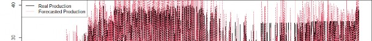

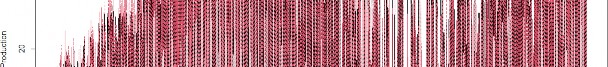

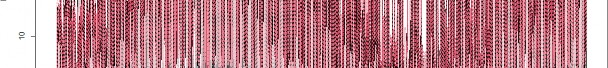

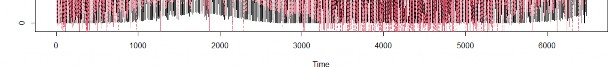

   Figure 1: Hourly production rates forecasted with ARIMA (p,d,q) = (4,1,2)

   WMAPE : 0.2215882

### b.ARIMA Model II:

   After building the first model and performing some examinations about the performance of the model, we decided to extract the first 1200 data to have a steady time series by eliminating the nonstationary period of the production data. As it can be seen from the picture above, the capacity of production is continuously increasing until the 1200th index.

### Hourly Production

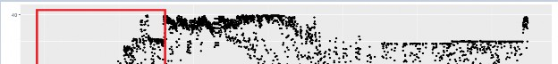

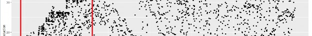

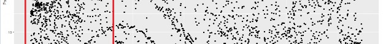

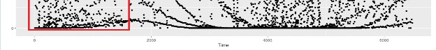

   Figure 2: Hourly production rates

   After eliminating the first part of the data, the same model is built by using the same configuration of the previous ARIMA model. The outputs of the second ARIMA model is as follows:

### Hourly Production

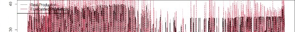

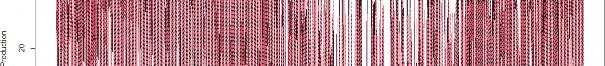

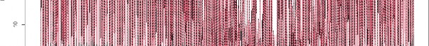

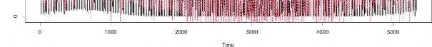

   WMAPE : 0.2208339

### c.ARIMA Model III:

   After observing the fact that removing the nonstationary part of the data has a positive effect on the performance of the ARIMA model, we decided to extend the removal window to obtain more stationary training data and use the last 1150 data to train the model. Moreover, we have used our theoretical backgrounds to find parameters for the SARIMA model instead of using the auto.arima function. Therefore, the autocorrelation and partial autocorrelation plots have been taken into consideration. The autocorrelation and partial autocorrelation functions are as follows:

### ACF Values of ARIMA Model III

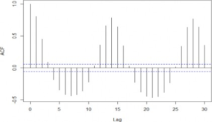

   Figure 4: ACF of ARIMA Model III

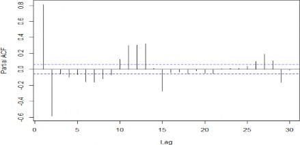

### Hourly Production

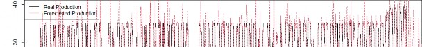

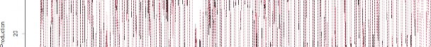

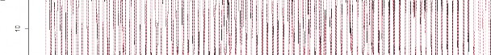

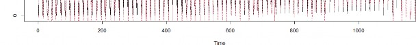

   Figure 6: SARIMA model results

   WMAPE = 0.1223735

   However, in our forecasting environment, we do not have data for yesterday so we can not use lag 14 in our model. Therefore the model having approx. 0.12 wmape is not valid to use for forecasting.

### d.Regression Model I:

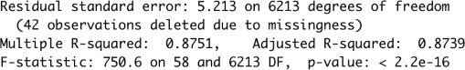

   Figure 7: Results of 1st regression model

### e.Regression Model II:

   As we discussed before we have added the multiplications of averages of variables and maximum capacities to examine their effect on the production. In the first stage, we thought to add only these regressors to the model since we thought they both disclose the effect of capacities and variables and relations between them.

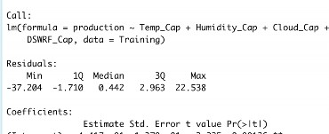

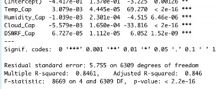

   Figure 8: Results of 2nd regression model

   As we can see in the output given above, the model has reached 0.8461 adjusted R squared by using only these 4 regressors. Then we have checked the distribution of residuals to see how we can improve the model.

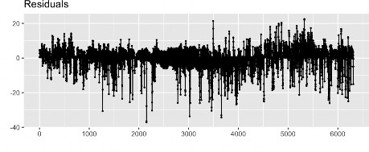

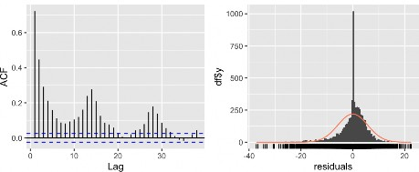

   Figure 9: Residual graphs of 2nd regression model

   When we examine the residual graphs, the seasonality can be observed easily in the ACF graph. The variance does not seem to be constant in the first graphs so the model can be improved by adding some new regressors and lag values to remove seasonality.

### f.Regression Model III:

   For the third model, we thought to use some important regressors which have already explained some of other regressors in the previous models and we decided to use only the last part of the original data for training since in the previous part of data, there is an increasing trend which we do not see in the last months. We have used only the flat section starting from mid-Feb to May.

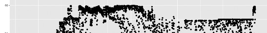

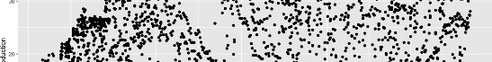

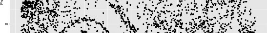

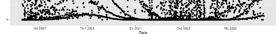

   Figure 10: The distribution of production over days

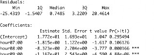

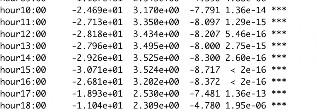

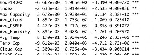

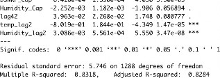

   Figure 11: Results of 3rd regression model

   Although this model has lower adjusted R^2 value compared to previous models, we thought to use it since it is easy to interpret if we do not have a deep performance gap. As we discussed earlier, we will try to use this model as a prior model for hourly model creation.